# nonmem2R goodness of fit plot functions

Magnus Åstrand

January 2019

## Introduction

Herein is a demo of functions for GOF plots in the nonmem2R R-package. The functions provide building blocks for doing GOF plots with flexibility for user specific formatting and or layout. There are also functions for combining single GOF’s into one and there are basic GOF’s combining a specific type of GOF’s into one single plot, e.g. the function `basic.GOF4` which generated the example below.

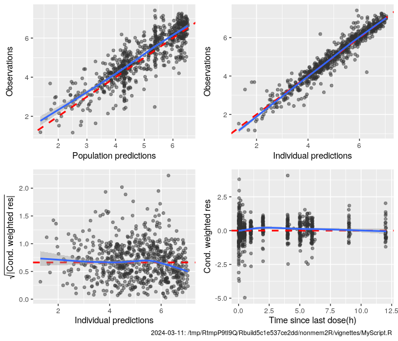

The GOF functions build on ggplot2 and as far as possible return an ggplot-object that can be further modified by adding ggplot formatting. However, some functions use `grid.arrange` from the R-package `gridExtra` to combine different type of GOF’s. These functions plot the combined set of GOF’s but does not return an ggplot object, and hence the plots can therefore not be easily further modified/formatted. To still provide options to add ggplot formatting these functions have an argument `global.ggplot.options` which can be used to add extra ggplot functions on each individual GOF before the GOF’s are combined into one graph by `grid.arrange`.

Formatting of e.g. lines and plot symbols can also be controlled by the argument `control` and the function `GOF.control` or using `set.GOF.params` to affect all GOF’s.

Axis labels are set for most common NONMEM variables, e.g. CWRES is by default labelled *“Cond. weighted res”* and TIME is by default labelled *“Time after first dose(h)”*. See examples in section **Labels and formatting options** with further details on controling axis labels, changing the caption text and other formatting of the GOF plots.

All GOF functions will by default add a caption in the bottom of the graph to indicate date when figure was generated together with the full path to the script. *However*, this require that the script name has been set using `set.script.name`, and then the script name will be pasted together with the date and path as derived from `getwd`. If script name has not been set no caption will be added. Each GOF plot will have a red dashed reference line and blue solid lines are smoother’s representing the actual data.

All functions require a data.frame as input and thus NONMEM output tables, e.g, sdtab, cotab,.., should be loaded prior using the functions, and if using multiple output tables it’s recommenced to just cbind all of them to a single sdtab data.frame.

## Functions

### Tailored GOF functions

There are a set of specific and tailored GOF functions.

`do.individual.GOF` will provide GOF plots of PRED, IPRED and DV vs TIME (default) with one panel per subject This will generate one page/plot per 20 subjects (default) and therefore this function is best used when exporting to a PDF. The X axis is default set to TIME but e.g. time after last dose (TAPD) or any column in the input data.frame. Below is a small example from 6 subjects.

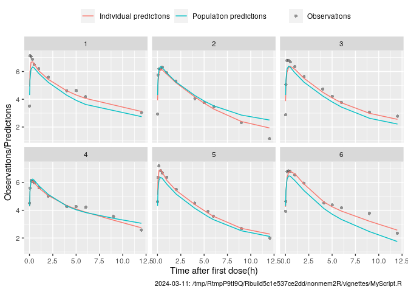

```r
do.individual.GOF(subset(sdtab,DV>0 & ID<7 & TIME<50))
```

On top of `basic.GOF4` with an example in the beginning of this document, there is also `basic.GOF6` which adds 2 extra GOF plots showing GOF’s for residuals (CWRES) as histogram and as qqnorm plot. Except for number of bins in the histogram of CWRES both have the same options and parameters, e.g. the X-axis value for 1’st and 2’nd GOF on the bottom row is set by `idv1` and `idv2`respectively. In the example below the defult (IPRED and TIME) is replaced by TAPD and PRED.

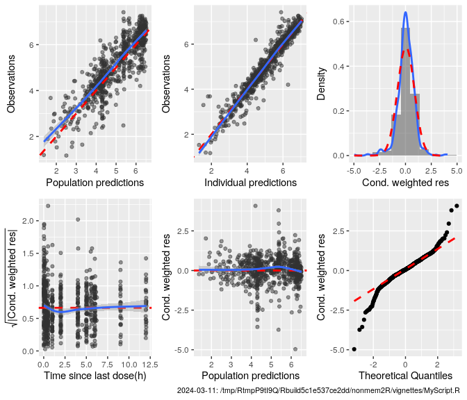

```r
basic.GOF6(subset(sdtab,DV>0),idv1="TAPD",idv2="PRED")
```

There are 4 tailored functions for doing GOF plots for ETA’s: `basic.eta.GOF`, `eta.cov.GOF`, `eta.cat.GOF`, and `eta.pairs.GOF`. These functions identifies all columns named `ETA1,..,ETA9,ET10,..` in the input data.frame and provides different types of GOF plots for these columns. All 4 functions will by default exclude ETA’s which are constant i.e. when set as FIX in your nonmem model (use `drop.fixed=FALSE` to override) and each ETA is scaled to unit variance (use `standardize=FALSE` to override). All but the `basic.eta.GOF` function return an ggplot object and can be further modified as any ggplot object.

`basic.eta.GOF` will provide GOF plots showing histograms and densities combined with QQ-norm plots.

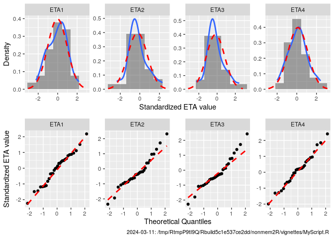

```r
basic.eta.GOF(sdtab)
```

`eta.cov.GOF` will provide GOF plots showing x-y plots of ETA’s vs continuous covariates and `eta.cat.GOF` will provide box-plots of all ETA’s. Both function have an argument `type` default set to “all-in-one”. This will generate a ggplot which is formatted by `facet_grid` with all ETA’s in rows and all covariates in columns, as in the example below for `eta.cov.GOF`.

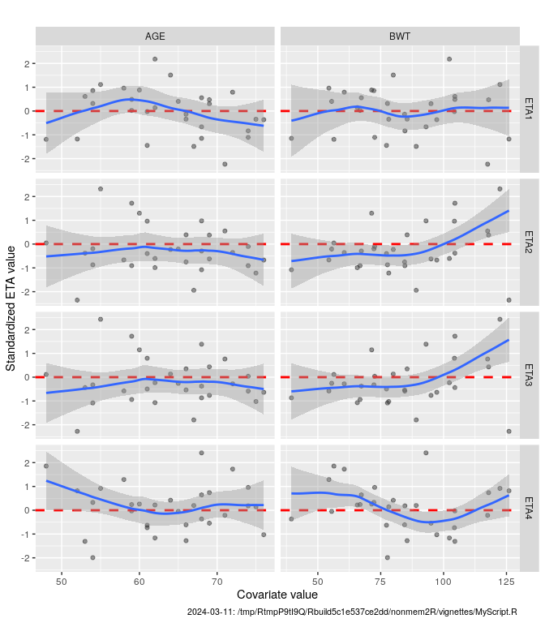

```r
eta.cov.GOF(subset(sdtab,DV>0),covariates=c("AGE","BWT"))
```

However it’s also possible to get either one page for each ETA (`type="eta-by-page"`) or as in the example below for `eta.cat.GOF` with one page for each covariate (`type="covariate-by-page"`).

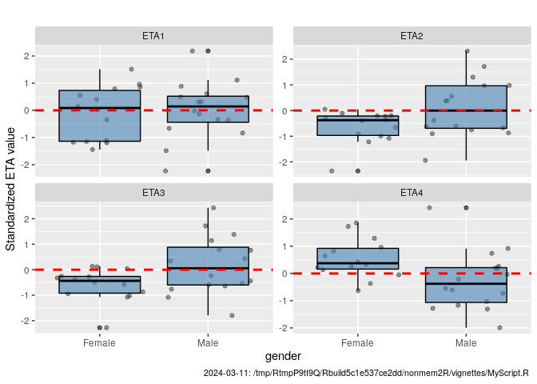

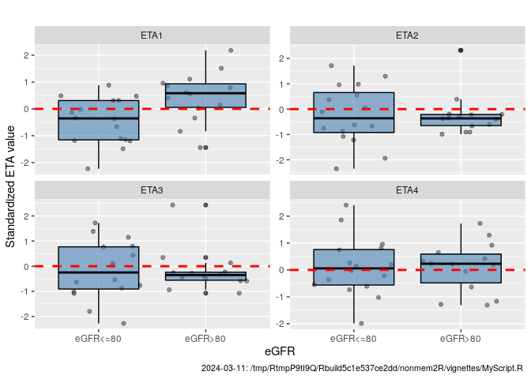

```r
eta.cat.GOF(subset(sdtab,DV>0),covariates=c("gender","eGFR"),type="covariate-by-page")
```

The last tailored function for doing GOF plots of ETA’s is `eta.pairs.GOF` with an example below. Default setting will show scatter plots below the diagonal, smooth density on the diagonal, and spearman correlations above the diagonal. A 2D density can also be added on either side of the diagonal. The example below is show the effect of setting labels for ETA using `set.GOF.params`

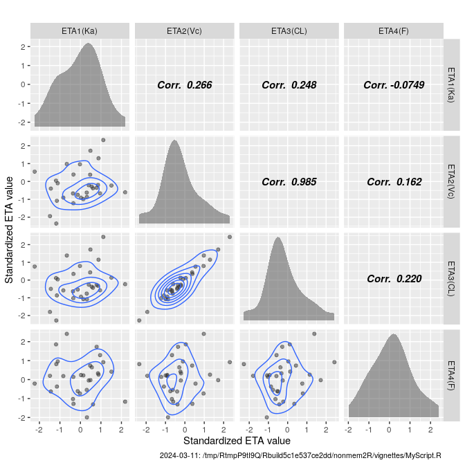

```r
set.GOF.params(eta.labels=c("Ka","Vc","CL","F"))
eta.pairs.GOF(sdtab,density2D="lower")
```

As mentioned some of the functions don’t return and ggplot object and the graph can thus not be further modified by adding existing ggplot functions. The functions do however have a named argument `global.ggplot.options` which is added to each individual ggplot functions before combining. This functionality is limited to one single additional ggplot function, e.g. `facet_grid`, `facet_wrap` or different theme’s such as `theme_bw`.

In the example below `basic.GOF4` is modified be setting `global.ggplot.options` to `facet_wrap(~gender)` to get one panel for each gender for each of the four GOF plots.

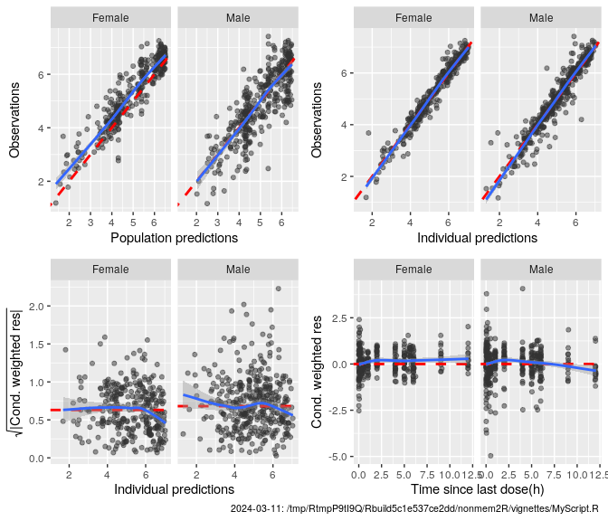

```r
basic.GOF4(subset(sdtab,DV>0),idv2="TAPD",global.ggplot.options=facet_wrap(~gender))
```

And in the example below `basic.GOF6` is modified be setting `global.ggplot.options` to `theme_classic()`

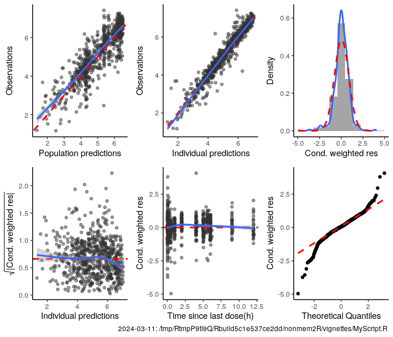

```r
basic.GOF6(subset(sdtab,DV>0),idv2="TAPD",global.ggplot.options=theme_classic())
```

### Labels and formatting options

#### Labels

```r
set.GOF.dictionary(TAD="Time since last dose(days)")
set.GOF.dictionary(TIME="Time since first dose(days)")
```

Use `get.GOF.dictionary` to inspect the complete *dictionary* of labels and `default.GOF.dictionary` to reset all labels to the default. It is also possible to turn of functionality and instead have column names as is for axis labels by setting the global GOF parameter `axis.labels` to `FALSE`. See next section for how to change global GOF parameters.

```r
get.GOF.dictionary()
```

```
## $DV
## [1] "Observations"
##
## $PRED
## [1] "Population predictions"
##
## $IPRED
## [1] "Individual predictions"
##
## $CWRES
## [1] "Cond. weighted res"
##
## $IWRES
## [1] "Ind. weighted res"
##
## $WRES
## [1] "Weighted residual"
##
## $RES
## [1] "Residual"
##
## $TIME
## [1] "Time since first dose(days)"
##
## $TAPD
## [1] "Time since last dose(h)"
##
## $TAD
## [1] "Time since last dose(days)"
##
## $TAFD
## [1] "Time after first dose(h)"
```

#### Formatting with set.GOF.params

The formatting of lines, plot symbols and caption text is controlled by the argument `control` with default values controlled by the current setting of GOF parameters. A default setting of parameters is set on loading `nonmem2R` *BUT* can be modified using `set.GOF.params`. For example to change plot symbols for one GOF use `control=GOF.control(pch.data = 1)` to get circles instead of the default which is points (`pch=19`). To change so that all GOF’s within a script or project get a different formatting, instead use `set.GOF.params(pch.data = 1)`, see below example.

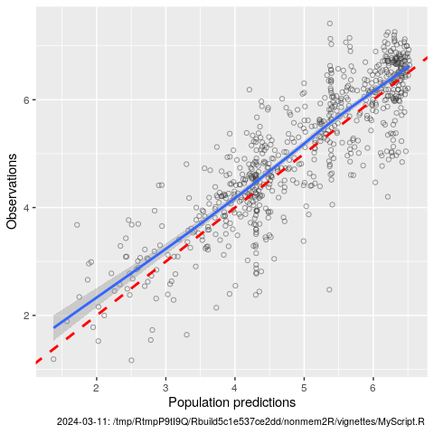

```r
set.GOF.params(pch.data = 1)
do.one.GOF(subset(sdtab,DV>0),"PRED","DV")
```

The format of the caption can be changed to have a different colour or font size either for only one GOF using the `control` argument, or for all GOF’s using the `set.GOF.params`. In the below example the formatting is changed to a larger font size, and the captions only displays a partial path including only 3 folders. (We change back to the default after using basic.GOF4)

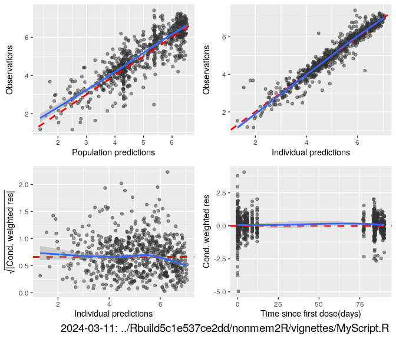

```r
set.GOF.params(caption.path.depth=3,size.caption = 14,pch.data = 19)
basic.GOF4(subset(sdtab,DV>0))
```

```r
### Change back to default
set.GOF.params(caption.path.depth=99,size.caption =8)
```

The caption text is set by the function `get.caption` which also is a GOF parameter that can be modified like any other GOF parameter using `set.GOF.params`. The default caption as shown in all examples above is a one-row caption with date and full path to the script. In the below example the `get.caption` function is modified to instead put the path to current working directory, the scripts name, and the date on separate rows. If modifying the function for caption text please not that the `get.caption` GOF parameter must be just that; a function with no argument returning a character string.

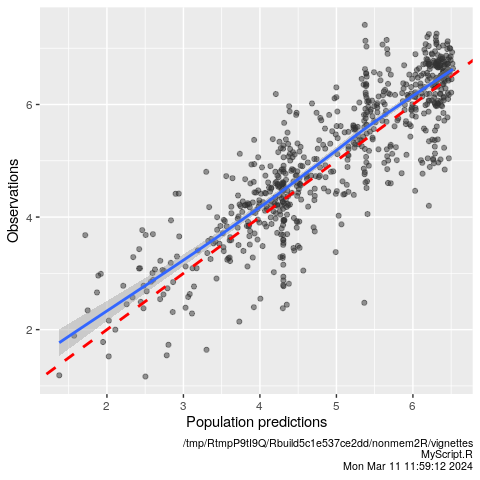

```r
set.GOF.params(
  get.caption=function(x){
      paste(getwd(),get.GOF.params()$script.name,date(),sep="\n")
      }
  )
do.one.GOF(subset(sdtab,DV>0),"PRED","DV")
```

Note that there is no check that the new value set for a GOF parameter make sense. To list all GOF parameters use `get.GOF.params` and `default.GOF.params` to reset all GOF parameters to the default. See section Details in packages documention for `get.GOF.params`.

```r
get.GOF.params()
```

```
## $col.data
## [1] "gray20"
##
## $cex.data
## [1] 1.5
##
## $pch.data
## [1] 19
##
## $alpha.data
## [1] 0.5
##
## $col.smooth
## [1] "#3366FF"
##
## $lty.smooth
## [1] 1
##
## $lwd.smooth
## [1] 1
##
## $se.smooth
## [1] TRUE
##
## $span.smooth
## [1] 0.6666667
##
## $degree.smooth
## [1] 1
##
## $family.smooth
## [1] "symmetric"
##
## $col.refline
## [1] "red"
##
## $lty.refline
## [1] 2
##
## $lwd.refline
```

[output cut: 33 more lines]

```
## [1] 99
##
## $get.caption
## function(x){
##       paste(getwd(),get.GOF.params()$script.name,date(),sep="\n")
##       }
##
## $corr.fontface
## [1] 4
##
## $eta.labels
## [1] "Ka" "Vc" "CL" "F"
##
## $script.name
## [1] "MyScript.R"
```

### GOF building block’s

This set of functions serve as building blocks for creating your own favourite set of graphs. All return an ggplot object and the output can therefore be further modified.

`do.one.GOF` is a simple x-y plot where you specify variables as strings, a smoother is added by default (blue line) but can be omitted. A red ref-line at y~x (default), or horizontal (at median or mean) can also be added. There are also options for the smoother. In the below example observed data (DV) is plotted versus predictions (PRED) and the graph is stratified by gender by adding the ggplot2 function `facet_wrap`.

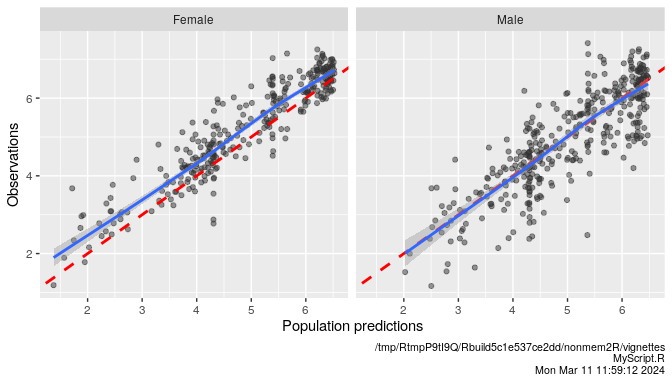

```r
do.one.GOF(subset(sdtab,DV>0),x="PRED",y="DV")+facet_wrap(~gender)
```

`do.multi.GOF` do multiple y-x plots where x is shared. A smoother is added by default, but reference lines are however omitted but can be added with similar options as for `do.one.GOF`. Adding additional ggplot functions can be done similar as for `do.one.GOF` e.g. the ggplot function `theme_bw` as in the below example. However, since the multi-panel layout is generated by the facet `facet_wrap(~variable)`, if modifying or adding additional facet’s it’s important to keep separate panels by `variable` and the recommend option is to use `facet_grid`. For example, adding `facet_grid(variable~gender)` will provide a `do.multi.GOF` stratified by gender.

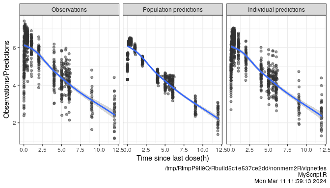

```r
do.multi.GOF(subset(sdtab,DV>0),x="TAPD",y=c("DV","PRED","IPRED"))+theme_bw()
```

`histGOF` and `qqnormGOF` provide GOF’s for residuals and ETA’s to check for assumption of normality. As for the other GOF’s red lines are reference lines, blue lines are smoother’s representing the actual data. For `histGOF` this is a smooth density whereas there is no smoother option for `qqnormGOF`. We demonstrate these functions by adding extra ggplot functions, in this case `facet_wrap` to stratify by time after dose into four categories.

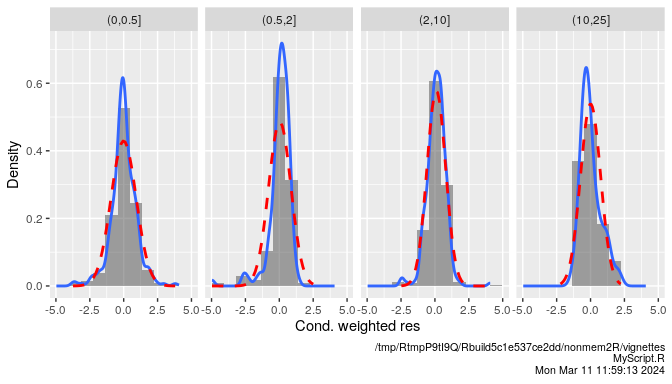

```r
sdtab$TAPDgr<-cut(sdtab$TAPD,breaks=c(0,0.5,2,10,25))
histGOF(subset(sdtab,DV>0),"CWRES")+facet_wrap(~TAPDgr,nrow=1)
```

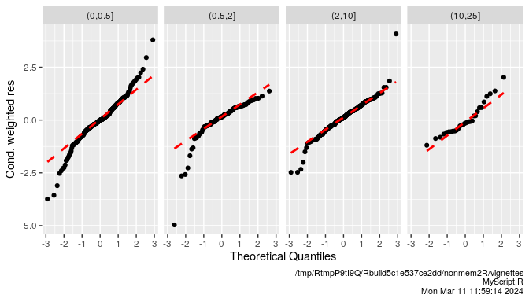

```r
qqnormGOF(subset(sdtab,DV>0),"CWRES")+facet_wrap(~TAPDgr,nrow=1)
```

`eta.hist.GOF` and `eta.qqnorm.GOF` are functions specific for ETA columns in NONMEM output tables. The functions identifies all columns named `ETA1,..,ETA9,ET10,...` and provide a GOF plot stratified by the ETA columns found. They provide similar type of graphs as `histGOF` and `qqnormGOF`. As for `do.multi.GOF` the function use `facet_wrap(~variable)`. The recommend option to add or modify facet is to use `facet_grid`. For example, adding `facet_grid(gender~variable)` will provide a GOF of ETA’s stratified by gender.

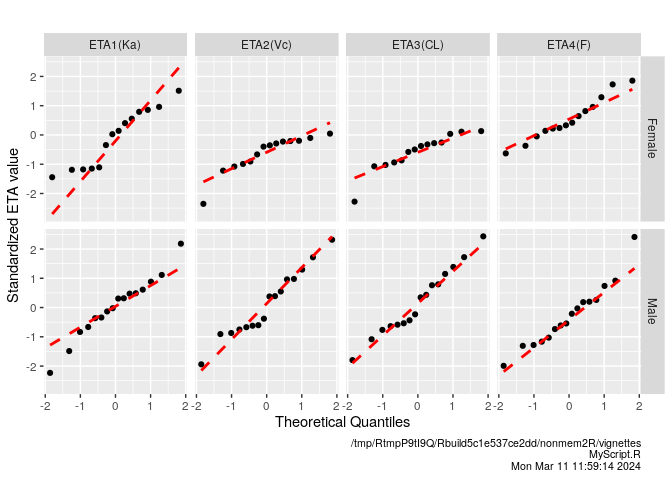

```r
eta.qqnorm.GOF(subset(sdtab,DV>0))+facet_grid(gender~variable)
```

### GOF builders

Finally, there are also a set of functions that can be used to combine any type of ggplot objects and plot them in one single graph: `merge2GOF`, `merge4GOF`, and `merge6GOF`. They differ in how many graphs they can combine: 1x2, 2x2, and 2x3, otherwise they share the same set of arguments.

In the example below GOF building blocks and GOF builders are used to generate a graph similar to `basic.GOF4`.

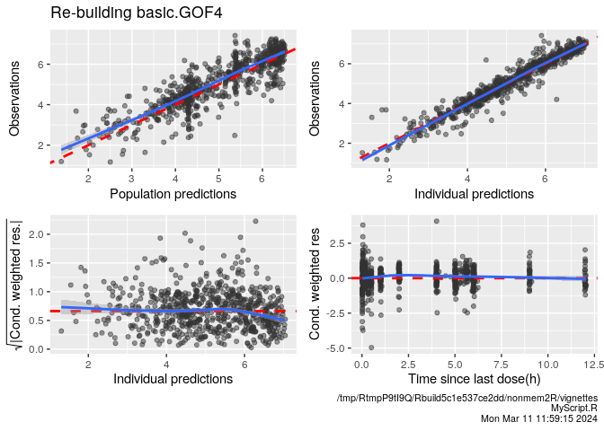

```r
p1<-do.one.GOF(subset(sdtab,DV>0),
               "PRED",
               "DV",
               control=GOF.control(add.caption=FALSE)) + labs(title="Re-building basic.GOF4")
p2<-do.one.GOF(subset(sdtab,DV>0),
               "IPRED",
               "DV",
               control=GOF.control(add.caption=FALSE))
sqrt.abs<-function(x){sqrt(abs(x))}
p3<-do.one.GOF(subset(sdtab,DV>0),
               "IPRED",
               "CWRES",
               refline="hrefmedian",
               fy=sqrt.abs,
               control=GOF.control(add.caption=FALSE)) + labs(y=a<-expression(sqrt('|Cond. weighted res.|')))
p4<-do.one.GOF(subset(sdtab,DV>0),
               "TAPD",
               "CWRES",
               refline="href0")
merge4GOF(p1,p2,p3,p4)
```